# labrador retriever image gets 813685 favorites/likes on twitter!!

[figure not shown]

The WeRateDogs Twitter archive contains basic tweet data for all 5000+ of their tweets, but not everything. One column the archive does contain though: each tweet's text, which I used to extract rating, dog name, and dog "stage" (i.e. doggo, floofer, pupper, and puppo) to make this Twitter archive "enhanced." Of the 5000+ tweets, I have filtered for tweets with ratings only (there are 2066 ).

[figure not shown]

More than **60%** of dog tweets about **pupper** dogs, more than **30%** about **doggo**. The pupper dogs should be the most popular on twitter!

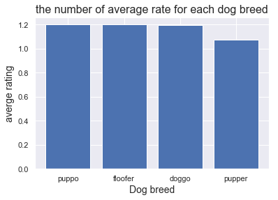

[figure not shown]

however, the average rating of pupper tweets is 1.07 which is the lowest average rate.

### if we take a look at the tweets dog bread we can see:

[figure not shown]

The golden retriever bread has about 150 tweets sharing their photos, as it's really large number because the next largest one is Labrador retriever with only 100 tweets from 2066 tweet.

### if we take a look on the retweets source:

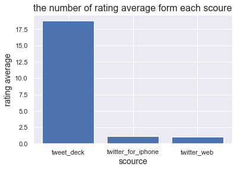